# Examining Factors Responsible for Heart Attacks

### Bivariate Analysis

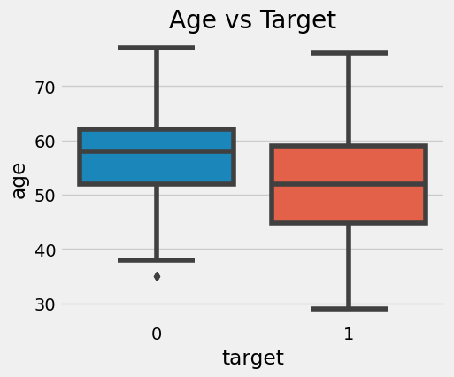

```python
# age vs target
plt.style.use('fivethirtyeight')
plt.figure(figsize=(5,4))
sns.boxplot(df, x='target', y='age')
plt.title('Age vs Target')
plt.show()
```

- **More chances of heart attacks occuring in the 45-60 age range**

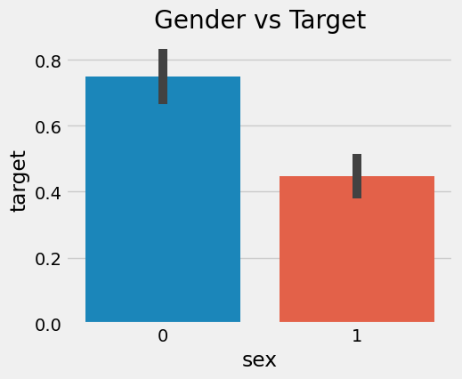

```python
# gender vs target
plt.style.use('fivethirtyeight')
plt.figure(figsize=(5,4))
sns.barplot(df, x='sex', y='target')
plt.title('Gender vs Target')
plt.show()
```

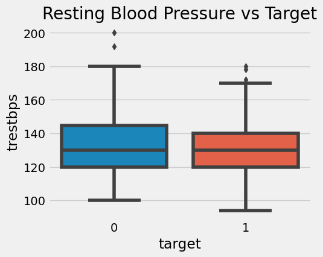

```python
# trestbps vs target
plt.style.use('fivethirtyeight')
plt.figure(figsize=(5,4))
sns.boxplot(df, x='target', y='trestbps')
plt.title('Resting Blood Pressure vs Target')
plt.show()
```

- More chances of a heart attack are seen in the resting blood pressure range of 120 and 140 mark

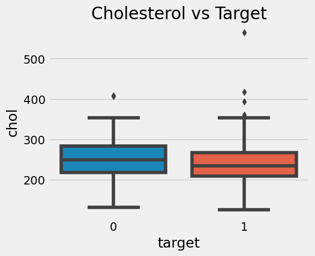

```python
# chol vs target
plt.style.use('fivethirtyeight')
plt.figure(figsize=(5,4))
sns.boxplot(df, x='target', y='chol')
plt.title('Cholesterol vs Target')
plt.show()
```

- Cholesterol values for targets appear almost the same.
- Outliers of more chance of heart attack is more prominent

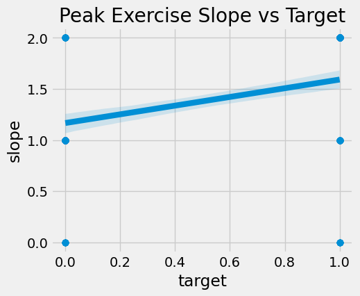

```python
# slope vs target
plt.style.use('fivethirtyeight')
plt.figure(figsize=(5,4))
sns.regplot(df, x='target', y='slope')
plt.title('Peak Exercise Slope vs Target')
plt.show()
```

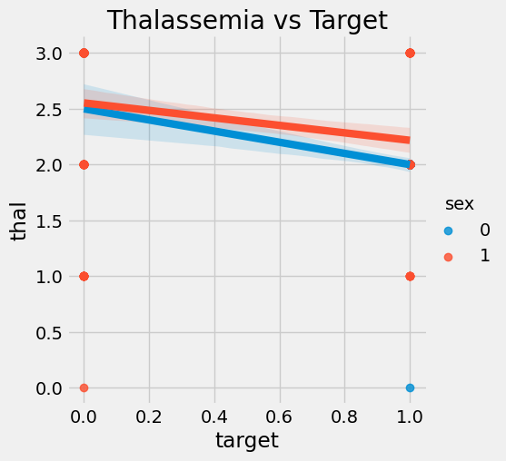

```python
# thal vs target
plt.style.use('fivethirtyeight')
plt.figure(figsize=(5,4))
sns.lmplot(df, x='target', y="thal", hue='sex')
plt.title('Thalassemia vs Target')
plt.show()
```

  > Additonal variable description corrections need to be applied for 'thal' column as follows:  
  > thal value 0 = Silent carrier  
  > thal value 1 = Mild carrier  
  > thanl value 2 = Reverseable carrier  
  > thal value 3 = Fixed defect carrier

### Correlations of Variables:

Understanding the relationships between features

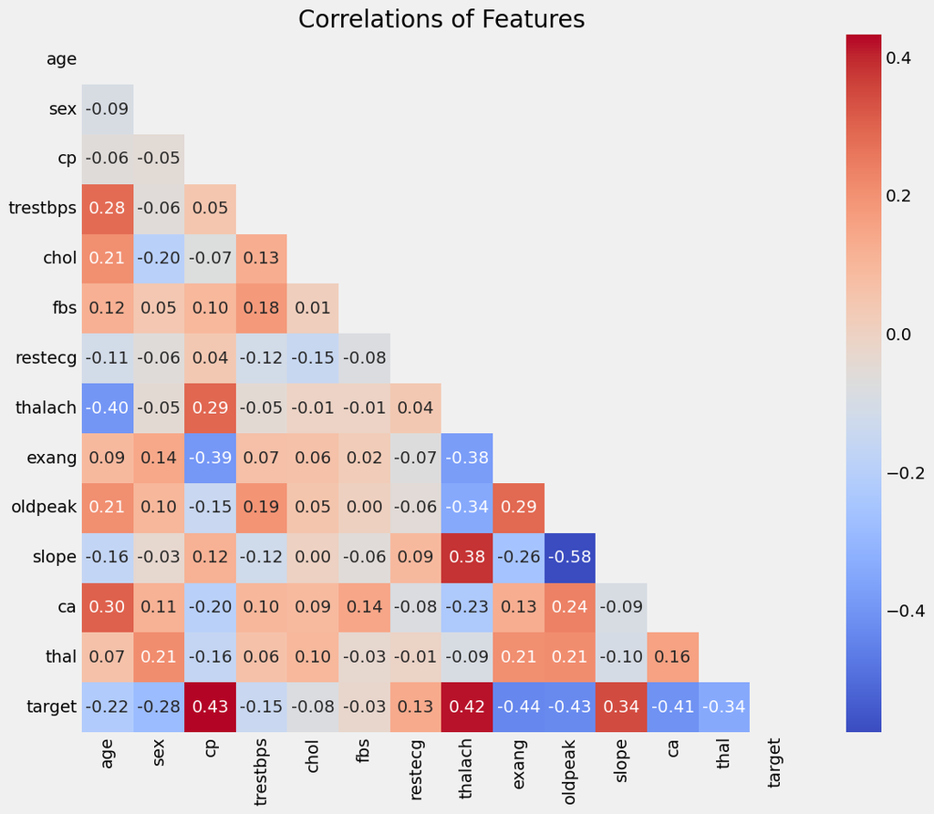

```python
# view correlations of features with heatmap

plt.figure(figsize=(12,10))
df_corr = df.corr()
mask = np.triu(np.ones_like(df_corr))
sns.heatmap(df_corr, cmap='coolwarm', annot=True, mask=mask, fmt='.2f')
plt.title('Correlations of Features')
plt.show()
```

Observations:

- **'target' is positively correlated to 'cp', 'thalach', 'slope', by 0.43, 0.42 and 0.34 respectively. This may indicate that the higher the value of 'cp', 'thalach' and 'slope', the more likely the occurence of an heart attack.**
- There is a negative correlation -0.58 between 'slope' and 'oldpeak'
- 'target' has negative correlations with ''exang', 'oldpeak', and 'ca' by -0.44, -0.43 and -0.41, respcetively.
- 'thalach' has negative correlations with 'exang' and 'oldpeak', of -0.38 and -0.34 respectively
- 'exang' and 'oldpeak' have a correlation of 0.29
- 'oldpeak' and 'ca' have acorrelation of 0.24

## Pairplot of All Features

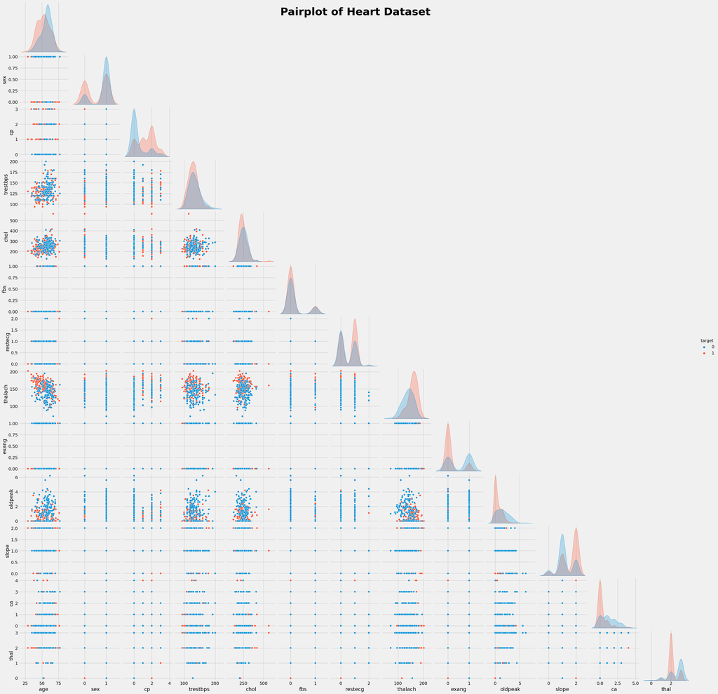

```python
# pairplot of entire df
plt.style.use('fast')
sns.pairplot(df, hue='target', corner=True)
plt.suptitle('Pairplot of Heart Dataset', fontsize='35', fontweight='heavy')
plt.show()
```

### Pairplot of Numerical Features by Target

```python
num_data = ['age','trestbps','chol','thalach','oldpeak', 'target']
```

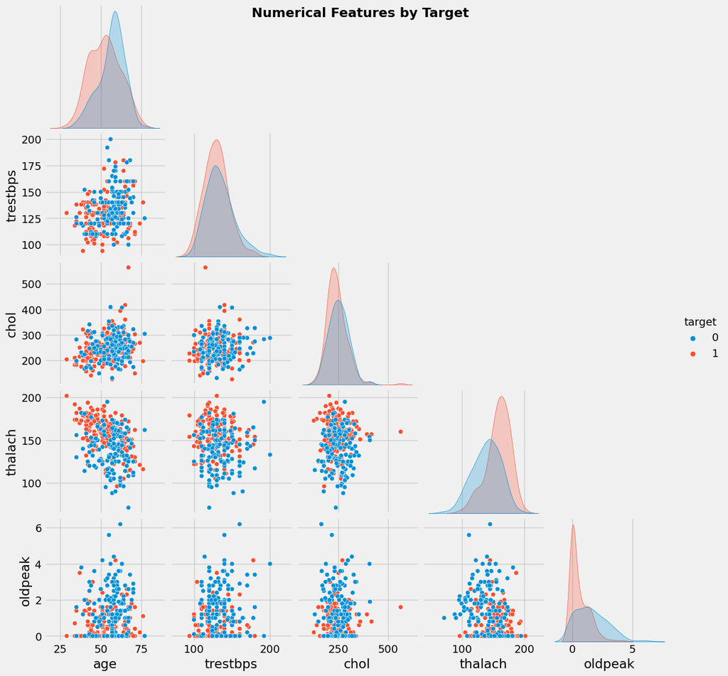

```python
# Numerical Features
plt.style.use('fast')
sns.pairplot(df[num_data], hue='target', corner=True)
plt.suptitle('Numerical Features by Target', fontsize='17', fontweight='heavy')
plt.show()
```

```python
df.to_excel('cleaneddata.xlsx')
```

# 4. Model Development: Logistic Regression

### i. Import Modelling Modules

```python
# import modelling modules
from sklearn.linear_model import LogisticRegression
from sklearn.preprocessing import StandardScaler
from sklearn.model_selection import train_test_split, GridSearchCV
from sklearn.metrics import confusion_matrix, accuracy_score
```

### ii. Select Features for Analysis

```python
# declare feature selection:
# trestbps, chol, fbs and restecg will be dropped due to their very low correlation values to target

x = df.drop(columns=['trestbps', 'chol', 'fbs', 'restecg', 'target'])
y = df['target']
```

### iii. Assess Indicator Variables

```python
# confirm features are already encoded as per the variable description
print(df.apply(lambda col: col.unique()))
```

```
age         [63, 37, 41, 56, 57, 44, 52, 54, 48, 49, 64, 5...
sex                                                    [1, 0]
cp                                               [3, 2, 1, 0]
trestbps    [145, 130, 120, 140, 172, 150, 110, 135, 160, ...
chol        [233, 250, 204, 236, 354, 192, 294, 263, 199, ...
fbs                                                    [1, 0]
restecg                                             [0, 1, 2]
thalach     [150, 187, 172, 178, 163, 148, 153, 173, 162, ...
exang                                                  [0, 1]
oldpeak     [2.3, 3.5, 1.4, 0.8, 0.6, 0.4, 1.3, 0.0, 0.5, ...
slope                                               [0, 2, 1]
ca                                            [0, 2, 1, 3, 4]
thal                                             [1, 2, 3, 0]
target                                                 [1, 0]
dtype: object
```

### iv. Split data into Training & Test Sets

```python
# split the dataset into training and test set

x_train, x_test, y_train, y_test = train_test_split(x, y, test_size=0.3, random_state=42)
print('Shape of Training & Testing Datasets:')
print("Train_x :",x_train.shape)
print("Test_x :",x_test.shape)
print("Train_y :",y_train.shape)
print("Test_y :",y_test.shape)
```

```
Shape of Training & Testing Datasets:
Train_x : (211, 9)
Test_x : (91, 9)
Train_y : (211,)
Test_y : (91,)
```

### v. Feature Scaling with StandardScaler

```python
# scale independant features only
# dependent variable is already valued at 0-1
scaler = StandardScaler()
x_train = scaler.fit_transform(x_train)
x_test = scaler.fit_transform(x_test)
```

### vi. Fit Logistic Regression to Training Set

```python
# fit trainining set into logreg object
logreg = LogisticRegression(random_state=0)
logreg.fit(x_train, y_train)
```

```
LogisticRegression(random_state=0)
```

### vii. Predict with Test set

```python
predict = logreg.predict(x_test)

# predicted values
predict
```

```
array([0, 0, 1, 0, 1, 1, 1, 0, 0, 1, 1, 0, 1, 0, 1, 1, 1, 0, 0, 0, 1, 0,
       0, 1, 1, 1, 0, 1, 0, 1, 0, 0, 1, 0, 1, 0, 1, 1, 1, 1, 1, 1, 1, 1,
       1, 0, 1, 1, 0, 0, 0, 0, 1, 1, 0, 0, 0, 1, 0, 1, 1, 1, 0, 0, 1, 1,
       1, 1, 1, 0, 1, 1, 1, 1, 0, 1, 1, 1, 0, 0, 0, 0, 1, 1, 1, 0, 0, 1,
       1, 0, 1], dtype=int64)
```

### viii. Check Accuracy

```python
print('Logistic Regression Accuracy Score is:', accuracy_score(y_test, predict)*100, '%')
```

```
Logistic Regression Accuracy Score is: 84.61538461538461 %
```

### ix. Fit Confusion Matrix into Test Set

```python
# fit confusion matrix into test set
conf_matrix = confusion_matrix(y_test, predict)
```

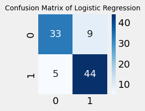

```python
# visualise confusion matrix
plt.figure(figsize=(2,2))
sns.heatmap(conf_matrix, annot=True, cmap='Blues')
plt.title('Confusion Matrix of Logistic Regression', fontsize='10')
plt.show()
```

### x. Model Performance

```python
# Calculating False Positives (FP), False Negatives (FN), True Positives (TP) & True Negatives (TN)

def model_performance(conf_matrix):

    FP = conf_matrix.sum(axis=0) - np.diag(conf_matrix)
    FN = conf_matrix.sum(axis=1) - np.diag(conf_matrix)
    TP = np.diag(conf_matrix)
    TN = conf_matrix.sum() - (FP + FN + TP)

    # Recall or true positive rate
    TPR = TP/(TP+FN)
    print ("The Recall (True Positive rate) per class is: ",TPR)


    # Precision or positive predictive value
    PPV = TP/(TP+FP)
    print ("The Precision per class is: ",PPV)

    # Overall accuracy
    ACC = (TP+TN)/(TP+FP+FN+TN)
    print ("The Accuracy of each class is", ACC)
    print("")

    ##Total averages :
    print ("The average Recall is: ",TPR.sum()/2)
    print ("The average Precision is: ",PPV.sum()/2)
    print ("The average Accuracy is", ACC.sum()/2)
```

**Model Performance: Recall, Precision and Accuracy**

```python
model_performance(conf_matrix)
```

```
The Recall (True Positive rate) per class is:  [0.78571429 0.89795918]
The Precision per class is:  [0.86842105 0.83018868]
The Accuracy of each class is [0.84615385 0.84615385]

The average Recall is:  0.8418367346938775
The average Precision is:  0.849304865938431
The average Accuracy is 0.8461538461538461
```

# 5. Tableau Dashboard

**Tableau Dashboard Link:** https://public.tableau.com/views/HeartAttackFactors_16738268795260/Dashboard1?:language=en-US&publish=yes&:display_count=n&:origin=viz_share_link